# Kaggle:Yelp:Restaurant Features: outdoor label classification:: YelpRest_nImgs_outside

## Step `10.0: predict data new`

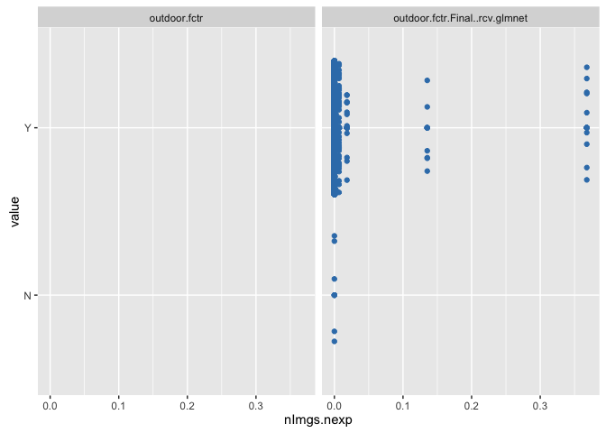

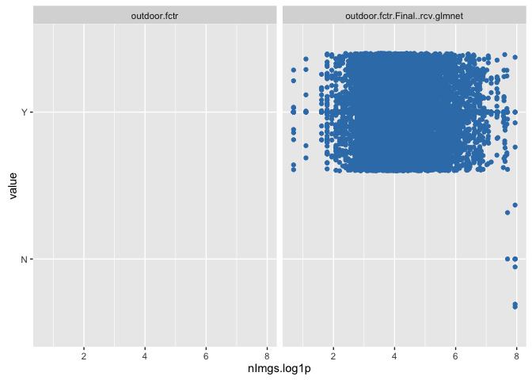

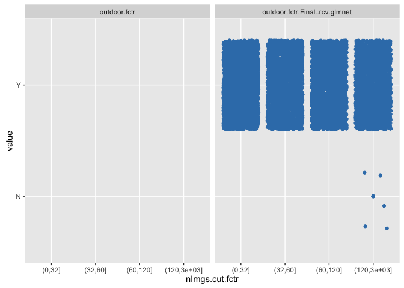

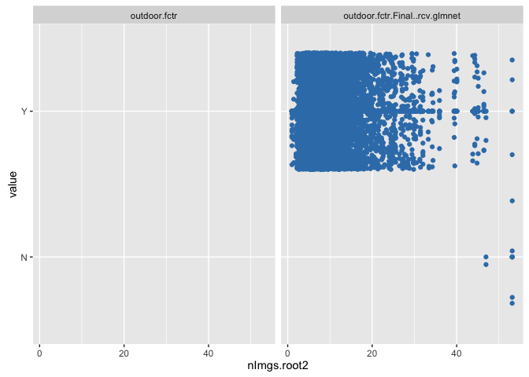

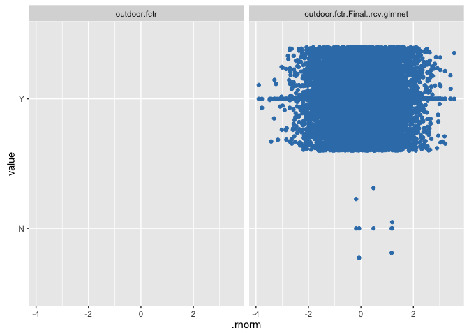

[output not shown]

[output cut: 203 more lines]

```
##      max.outdoor.fctr.N max.outdoor.fctr.Y min.outdoor.fctr.N
## .pos               2000               1997                  2
##      min.outdoor.fctr.Y max.outdoor.fctr.All.X..rcv.glmnet.Y
## .pos                  1                                 1999
##      min.outdoor.fctr.All.X..rcv.glmnet.Y
## .pos                                    1
##      max.outdoor.fctr.Final..rcv.glmnet.N
## .pos                                 6339
##      max.outdoor.fctr.Final..rcv.glmnet.Y
## .pos                                12000
##      min.outdoor.fctr.Final..rcv.glmnet.N
## .pos                                 2459
##      min.outdoor.fctr.Final..rcv.glmnet.Y
## .pos                                 2001
## [1] "newobs total range outliers: 10000"
```

```
## [1] TRUE
```

```
## [1] "ObsNew output class tables:"
## $lunch
##
##    -1
## 10000
##
## $dinner
##
##    -1
## 10000
##
## $reserve
##
##     2
## 10000
##
## $outdoor
##
##   -1    3
##    5 9995
##
## $expensive
##
##    -1
## 10000
##
## $liquor
##
##     5
## 10000
##
## $table
##
##     6
## 10000
##
## $classy
##
##    -1
## 10000
##
## $kids
##
##     8
## 10000
```

```
## [1] 0.3
```

```
## [1] "glb_sel_mdl_id: All.X##rcv#glmnet"
```

```
## [1] "glb_fin_mdl_id: Final##rcv#glmnet"
```

```
## [1] "Cross Validation issues:"
##        MFO###myMFO_classfr  Random###myrandom_classfr
##                          0                          0
## Max.cor.Y.rcv.1X1###glmnet
##                          0
```